# ex2

```python
!pip show astropy
```

```
Name: astropy
Version: 7.0.1
Summary: Astronomy and astrophysics core library
Home-page:
Author:
Author-email: The Astropy Developers <astropy.team@gmail.com>
License: BSD-3-Clause
Location: C:\Users\btcya\Desktop\astronomy-course-programming\astrocourse\Lib\site-packages
Requires: astropy-iers-data, numpy, packaging, pyerfa, PyYAML
Required-by:
```

### Import libraries

```python
import numpy as np
import matplotlib.pyplot as plt
from astropy import units as u
```

### Examples

- give examples how to add units to code

```python
a = 50.0 * u.meter
print(a)
b = [23,45,88] * u.meter

c = [4,7,10] * u.second
print(c)
```

```
50.0 m
[ 4.  7. 10.] s
```

### Explanation of the Code

1. **Create a New Figure**:
   - `plt.figure()`: Initializes a new figure for the plot.
2. **Plot Data Points**:
   - `plt.plot(b, c, 'o', label='Wind speed [m/s]')`:
     - Plots the data points `(b, c)` as circles (`'o'`).
     - Adds a label for the data points: "Wind speed [m/s]".
3. **Label Axes**:
   - `plt.xlabel('Speed [m\u2009/s]')`: Labels the x-axis as "Speed [m/s]" with a half-space interval between `m` and `/s`.
   - `plt.ylabel('Time [s]')`: Labels the y-axis as "Time [s]".
4. **Add a Legend**:
   - `plt.legend()`: Adds a legend to the plot to describe the data points.
5. **Generate Reference Line Data**:
   - `l1 = np.linspace(0, 100, 10)`: Creates an array of 10 evenly spaced points between 0 and 100.
   - `l2 = np.linspace(0, 100, 10)`: Creates another array of 10 evenly spaced points between 0 and 100.
6. **Plot a Reference Line**:
   - `plt.plot(l1, l2, color='gray', linestyle='--')`:
     - Plots a gray dashed line using `l1` and `l2` as the x and y coordinates.
     - This line serves as a reference or guide in the plot.

### Output:

- The plot will display:
  1. Data points `(b, c)` as circles labeled "Wind speed [m/s]".
  2. A gray dashed reference line from `(0, 0)` to `(100, 100)`.
  3. X-axis labeled as "Speed [m/s]" with a half-space interval.
  4. Y-axis labeled as "Time [s]".
  5. A legend describing the data points.

### Use Case:

This plot is useful for visualizing the relationship between speed and time, with a reference line for comparison.

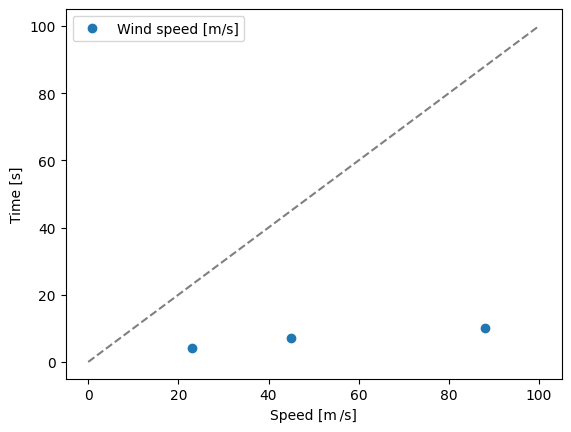

```python
# Create a new figure for the plot
plt.figure()

# Plot the data points (b, c) as circles with a label
plt.plot(b, c, 'o', label='Wind speed [m/s]')

# Label the x-axis with a half-space interval in the unit
plt.xlabel('Speed [m\u2009/s]')

# Label the y-axis
plt.ylabel('Time [s]')

# Add a legend to the plot
plt.legend()

# Generate two linearly spaced arrays for plotting a reference line
l1 = np.linspace(0, 100, 10)  # Array from 0 to 100 with 10 points
l2 = np.linspace(0, 100, 10)  # Array from 0 to 100 with 10 points

# Plot a gray dashed reference line using l1 and l2
plt.plot(l1, l2, color='gray', linestyle='--')
```